# Exploratory Data Analysis - Customer Satisfaction

### Data

This dataset contains survey data on customer satisfaction gathered by an airline company and can be found on Kaggle: https://www.kaggle.com/datasets/sjleshrac/airlines-customer-satisfaction

### Purpose

The aim of this analysis is to explore the data, uncover insights that can assist the airline company in better understanding its customers, and identify patterns that can drive further analysis projects.

```r
library(tidyverse)
```

Let’s load the data, take a first look at the structure and check for missing values

```r
airline <- read.csv('airline.csv')

str(airline)
```

```
## 'data.frame':    129880 obs. of  23 variables:
##  $ satisfaction                     : chr  "satisfied" "satisfied" "satisfied" "satisfied" ...
##  $ Gender                           : chr  "Female" "Male" "Female" "Female" ...
##  $ Customer.Type                    : chr  "Loyal Customer" "Loyal Customer" "Loyal Customer" "Loyal Customer" ...
##  $ Age                              : int  65 47 15 60 70 30 66 10 56 22 ...
##  $ Type.of.Travel                   : chr  "Personal Travel" "Personal Travel" "Personal Travel" "Personal Travel" ...
##  $ Class                            : chr  "Eco" "Business" "Eco" "Eco" ...
##  $ Flight.Distance                  : int  265 2464 2138 623 354 1894 227 1812 73 1556 ...
##  $ Seat.comfort                     : int  0 0 0 0 0 0 0 0 0 0 ...
##  $ Departure.Arrival.time.convenient: int  0 0 0 0 0 0 0 0 0 0 ...
##  $ Food.and.drink                   : int  0 0 0 0 0 0 0 0 0 0 ...
##  $ Gate.location                    : int  2 3 3 3 3 3 3 3 3 3 ...
##  $ Inflight.wifi.service            : int  2 0 2 3 4 2 2 2 5 2 ...
##  $ Inflight.entertainment           : int  4 2 0 4 3 0 5 0 3 0 ...
##  $ Online.support                   : int  2 2 2 3 4 2 5 2 5 2 ...
##  $ Ease.of.Online.booking           : int  3 3 2 1 2 2 5 2 4 2 ...
##  $ On.board.service                 : int  3 4 3 1 2 5 5 3 4 2 ...
##  $ Leg.room.service                 : int  0 4 3 0 0 4 0 3 0 4 ...
##  $ Baggage.handling                 : int  3 4 4 1 2 5 5 4 1 5 ...
##  $ Checkin.service                  : int  5 2 4 4 4 5 5 5 5 3 ...
##  $ Cleanliness                      : int  3 3 4 1 2 4 5 4 4 4 ...
##  $ Online.boarding                  : int  2 2 2 3 5 2 3 2 4 2 ...
##  $ Departure.Delay.in.Minutes       : int  0 310 0 0 0 0 17 0 0 30 ...
##  $ Arrival.Delay.in.Minutes         : int  0 305 0 0 0 0 15 0 0 26 ...
```

```r
print(colSums(is.na(airline)))
```

```
##                      satisfaction                            Gender
##                                 0                                 0
##                     Customer.Type                               Age
##                                 0                                 0
##                    Type.of.Travel                             Class
##                                 0                                 0
##                   Flight.Distance                      Seat.comfort
##                                 0                                 0
## Departure.Arrival.time.convenient                    Food.and.drink
##                                 0                                 0
##                     Gate.location             Inflight.wifi.service
##                                 0                                 0
##            Inflight.entertainment                    Online.support
##                                 0                                 0
##            Ease.of.Online.booking                  On.board.service
##                                 0                                 0
##                  Leg.room.service                  Baggage.handling
##                                 0                                 0
##                   Checkin.service                       Cleanliness
##                                 0                                 0
##                   Online.boarding        Departure.Delay.in.Minutes
##                                 0                                 0
##          Arrival.Delay.in.Minutes
##                               393
```

We can see that there are a total of 393 missing values - all in the Arrival.Delay.in.Minutes column. Let’s calculate how much of the total data is represented by the NA values.

```r
sum(is.na(airline)) / nrow(airline)
```

```
## [1] 0.00302587
```

The rows with values are only accounting for 0.3% of the total data, so for the purpose of this analysis we are going to remove them. After that we can check that we removed all NA rows successfully.

```r
clean_airline <- na.omit(airline)

sum(is.na(clean_airline$Arrival.Delay.in.Minutes))
```

```
## [1] 0
```

With all the NA values removed we can continue exploring our data.

Next, we are going to look at what type of travel is the most common.

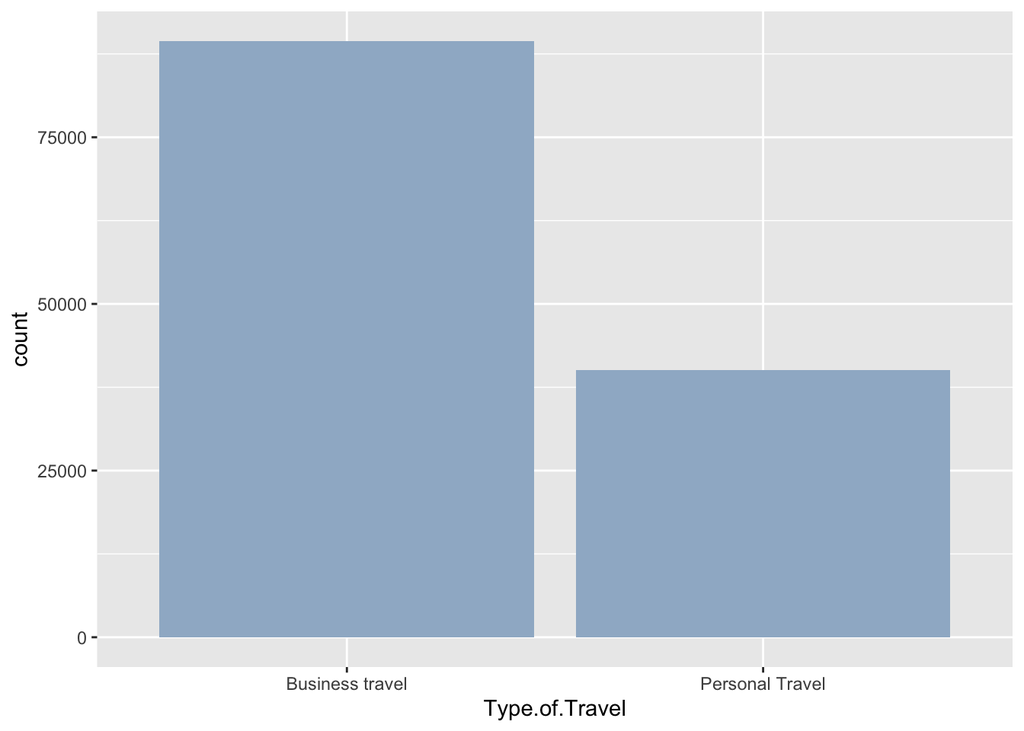

```r
ggplot(clean_airline, aes(Type.of.Travel)) +
  geom_bar(fill = 'Slategray3')
```

```r
sum(clean_airline$Type.of.Travel == 'Business travel') / nrow(clean_airline)
```

```
## [1] 0.6907643
```

We can see that Business travel is accounting for 69% of all travels.

Let’s look at the different classes.

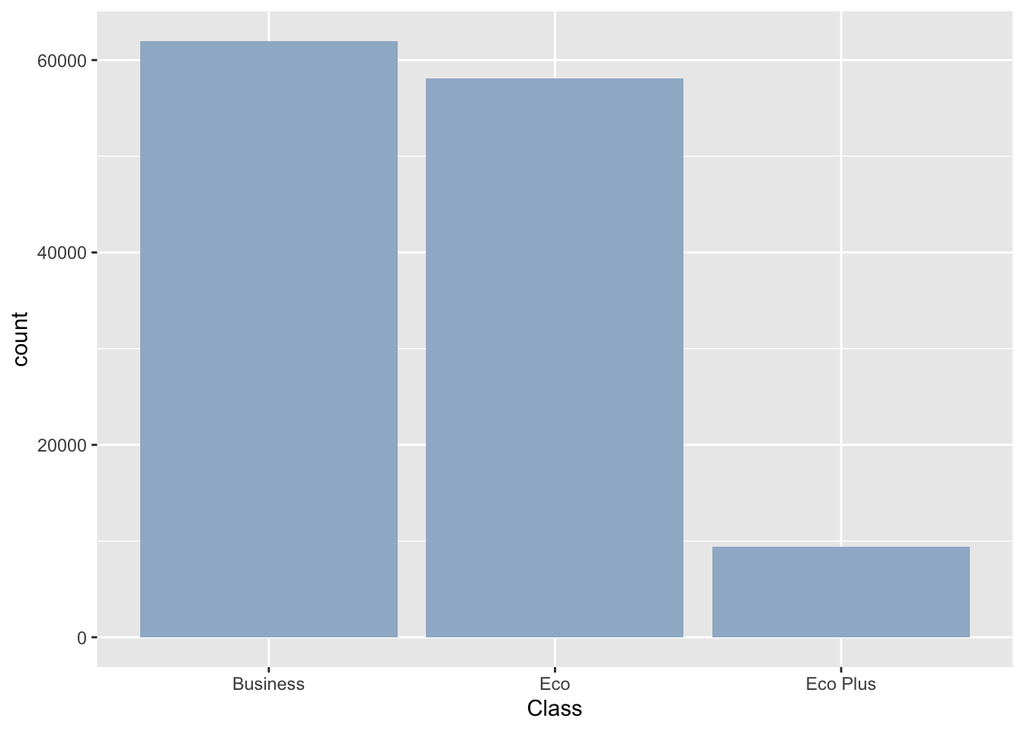

```r
ggplot(clean_airline, aes(Class)) +
  geom_bar(fill = 'Slategray3')
```

Here we can see that the overall spread between Business Class and Economy Class is pretty even.

If we filter for the two types of travel we can then check the most common class within each travel type.

```r
business <- clean_airline %>%
  filter(Type.of.Travel == 'Business travel')

personal <- clean_airline %>%
  filter(Type.of.Travel == 'Personal Travel')
```

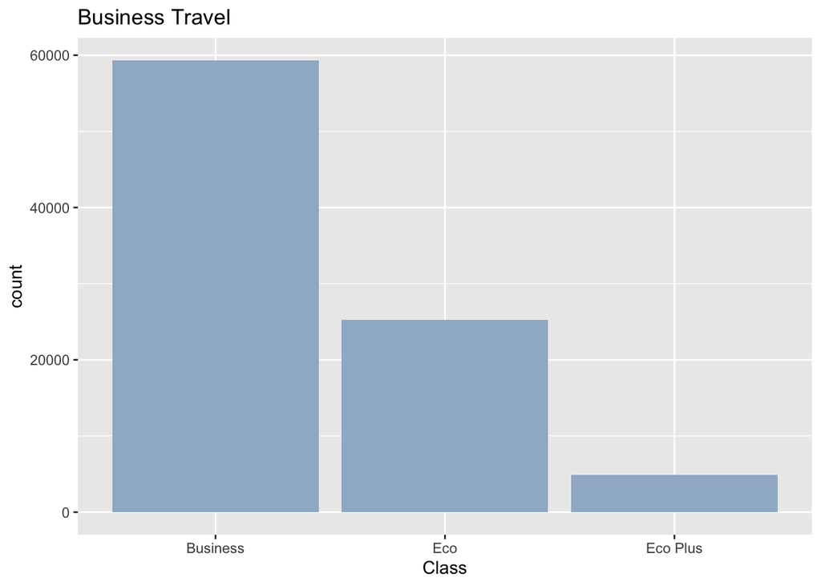

```r
ggplot(business, aes(Class)) +
  geom_bar(fill = 'Slategray3') +
  ggtitle('Business Travel')
```

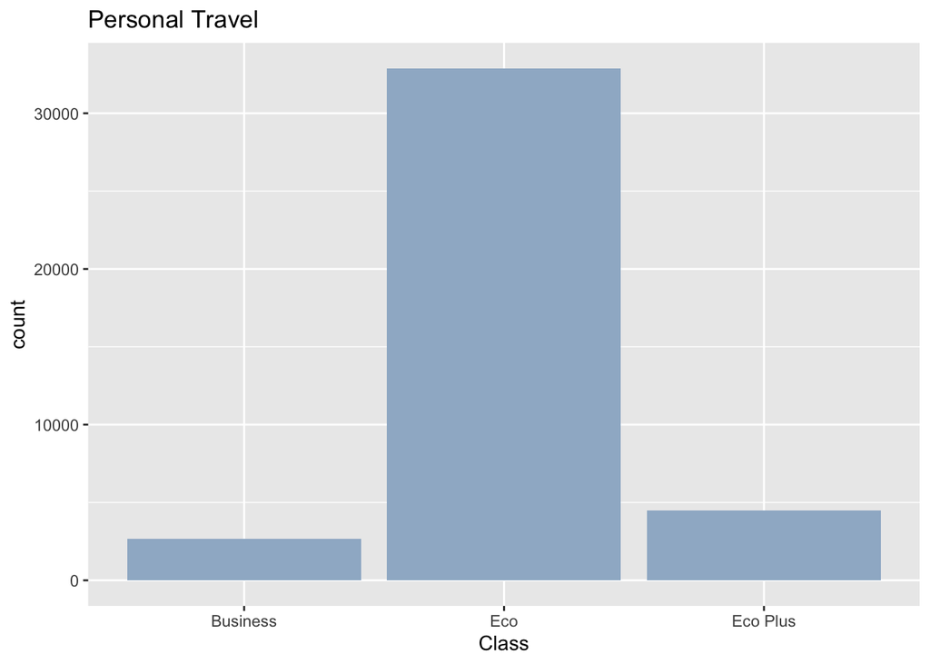

```r
ggplot(personal, aes(Class)) +
  geom_bar(fill = 'Slategray3') +
  ggtitle('Personal Travel')
```

Most of the Business travelers are choosing Business Class but there is still a large proportion of customers that is travelling in Economy or Economy Plus.

Customers that is making Personal travels are almost exclusively choosing Economy and Economy Plus.

Now let’s look at satisfaction.

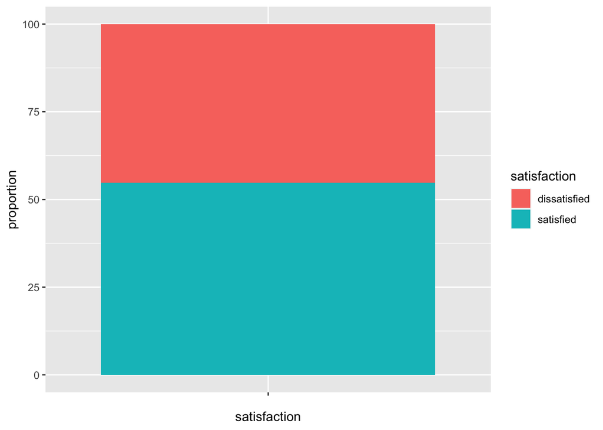

```r
overall_satisfaction <- clean_airline %>%
  group_by(satisfaction) %>%
  summarize(proportion = n() / nrow(.) * 100)

ggplot(overall_satisfaction, aes(x = '', y = proportion, fill = satisfaction)) +
  geom_col() +
  labs(x = 'satisfaction', y = 'proportion')
```

Looking at the overall satisfaction level, almost 55% of the airline customers are satisfied.

Breaking it down by type of travel it looks like this:

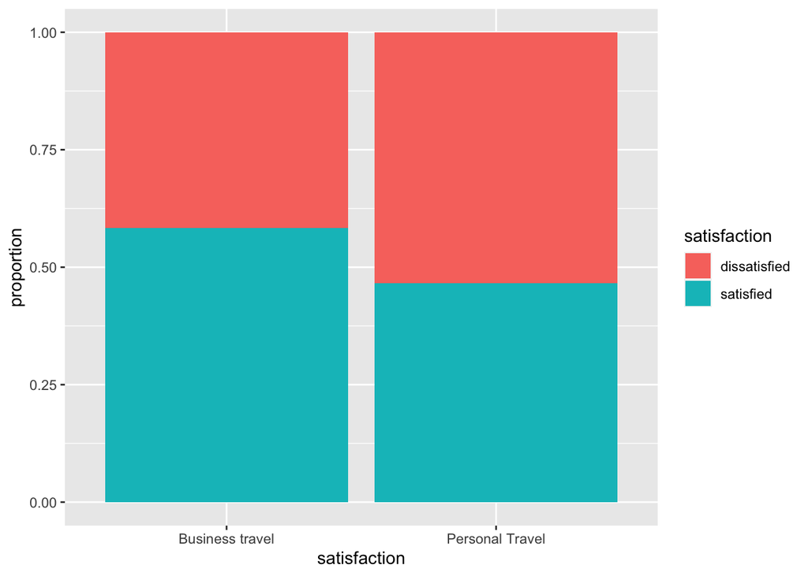

```r
type_of_travel_satisfaction <- clean_airline %>%
  group_by(Type.of.Travel, satisfaction) %>%
  summarize(count = n()) %>%
  mutate(proportion = count / sum(count))

ggplot(type_of_travel_satisfaction, aes(x = Type.of.Travel, y = proportion, fill = satisfaction)) +
  geom_col() +
  labs(x = 'satisfaction', y = 'proportion')
```

```r
type_of_travel_satisfaction
```

| Type.of.Travel | satisfaction | count | proportion |
| --- | --- | --- | --- |
| Business travel | dissatisfied | 37238 | 0.4163229 |
| Business travel | satisfied | 52207 | 0.5836771 |
| Personal Travel | dissatisfied | 21367 | 0.5336147 |
| Personal Travel | satisfied | 18675 | 0.4663853 |

We can see that customers making Business travels appear to be far more satisfied than those making personal travels.

Let’s move on to class.

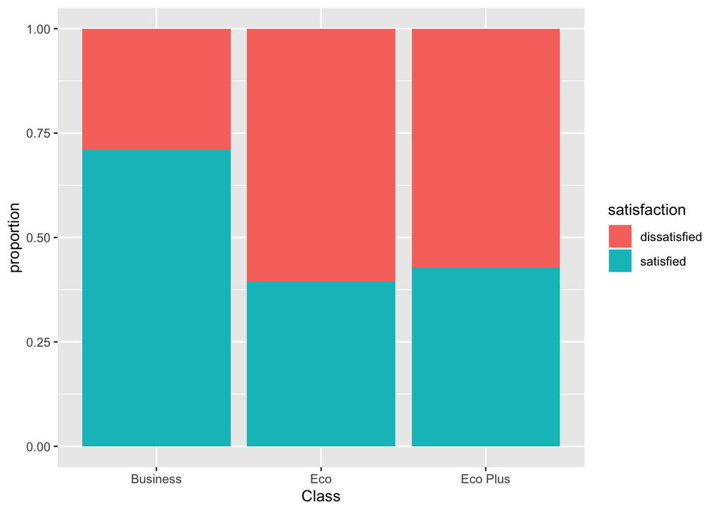

```r
class_satisfaction <- clean_airline %>%
  group_by(Class, satisfaction) %>%
  summarize(count = n()) %>%
  mutate(proportion = count / sum(count))

ggplot(class_satisfaction, aes(Class, proportion, fill = satisfaction)) +
  geom_col()
```

When we look at satisfaction levels between the different classes it becomes clear that customers travelling in Business Class are overall very satisfied. Unfortunately, customers in Economy and Economy Plus are not as satisfied with their experience.

Let’s break it down further and look at age.

```r
summary(clean_airline$Age)
```

```
##    Min. 1st Qu.  Median    Mean 3rd Qu.    Max.
##    7.00   27.00   40.00   39.43   51.00   85.00
```

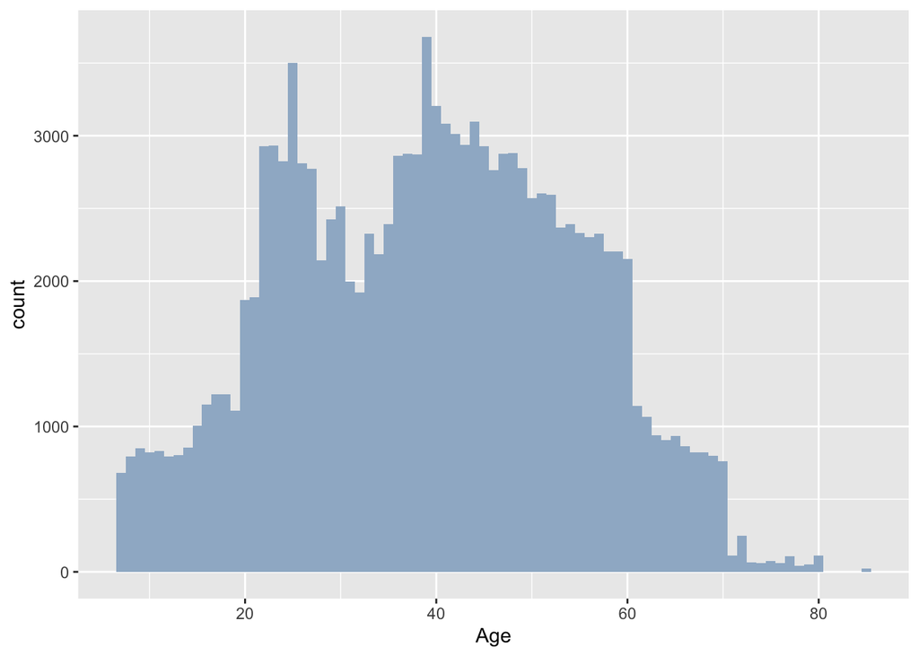

```r
ggplot(clean_airline, aes(x = Age)) +
    geom_histogram(binwidth = 1, fill = 'Slategray3')
```

From the summary statistics we can see that minimum age is 7, maximum age is 85 and the median age is 40. If we look at the distribution of age between customers, we can see that most of them are between the ages of 20-60.

Now let’s divide customers into age groups

```r
clean_airline <- clean_airline %>%
  mutate(Age.Group = case_when(
    Age >= 7 & Age <= 14 ~ '0-14',
    Age > 14 & Age <= 20 ~ '15-20',
    Age > 20 & Age <= 30 ~ '21-30',
    Age > 30 & Age <= 40 ~ '31-40',
    Age > 40 & Age <= 50 ~ '41-50',
    Age > 50 & Age <= 60 ~ '51-60',
    Age > 60 & Age <= 65 ~ '61-65',
    Age > 65 ~ '65+',
    TRUE ~ NA_character_
  ))

age_proportion <- clean_airline %>%
  group_by(Age.Group, satisfaction) %>%
  summarise(count = n()) %>%
  mutate(proportion = count / sum(count))
```

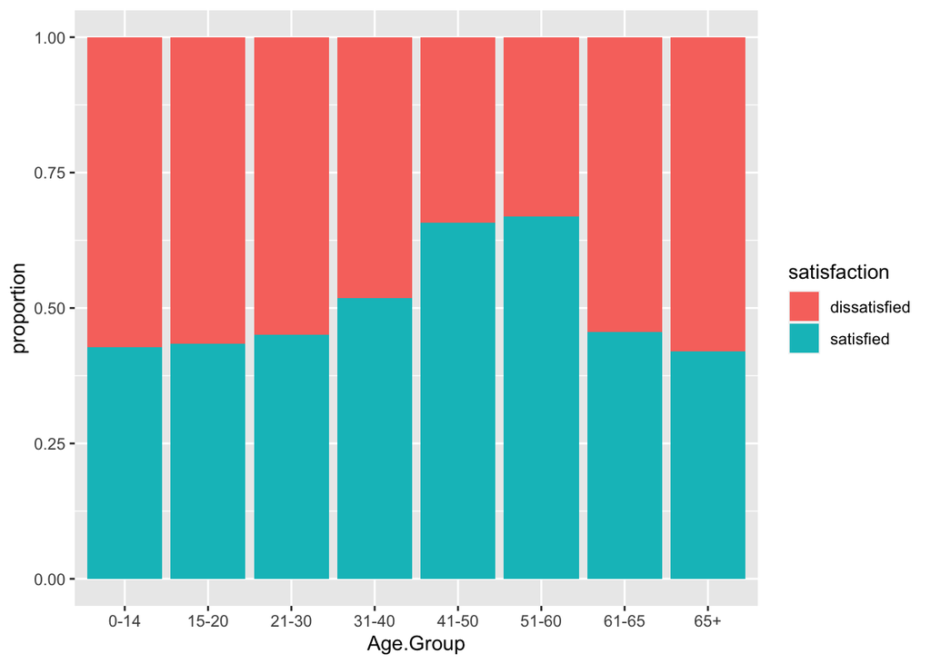

```r
ggplot(age_proportion, aes(x = Age.Group, y = proportion, fill = satisfaction)) +
    geom_col()
```

Here we can see that, overall, customers between 41-60 tend to be far more satisfied than any other age group.

Breaking it down by age groups and class looks like this:

```r
age_proportion <- clean_airline %>%
  group_by(Age.Group, Class, satisfaction) %>%
  summarise(count = n()) %>%
  mutate(proportion = count / sum(count))
```

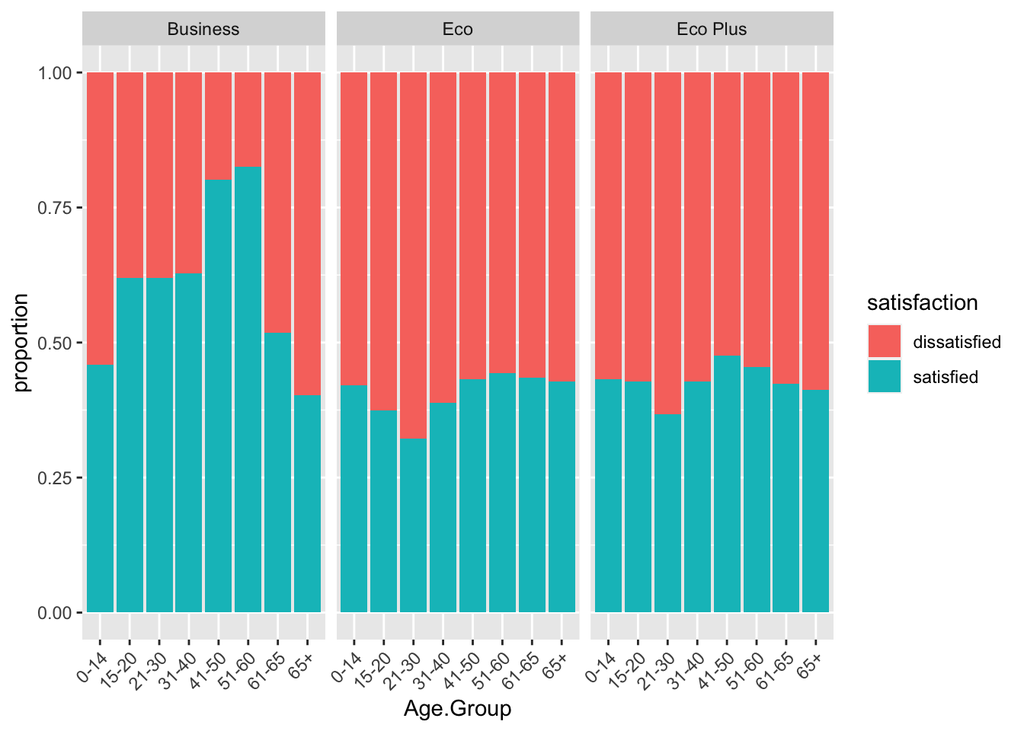

```r
ggplot(age_proportion, aes(x = Age.Group, y = proportion, fill = satisfaction)) +
    geom_col() +
    facet_wrap(~ Class) +
    theme(axis.text.x = element_text(angle = 45, hjust = 1)) +
    scale_x_discrete()
```

Looking at satisfaction levels between age groups within each class, we can clearly see that the least satisfied customers within Economy and Economy Plus are between 21-30. It also becomes clear that in Business Class, the ages 0-14 and 65+ are more dissatisfied than satisfied with their experience.

Let’s also check the correlation between satisfaction and the different types of services.

```r
clean_airline_numeric <- clean_airline %>%
  mutate(satisfaction = ifelse(satisfaction == 'satisfied',1,0)) %>%
  select_if(is.numeric)

correlation_matrix <- cor(clean_airline_numeric)

satisfaction_correlation <- correlation_matrix["satisfaction", ]
satisfaction_correlation <- satisfaction_correlation[order(-abs(satisfaction_correlation))]
```

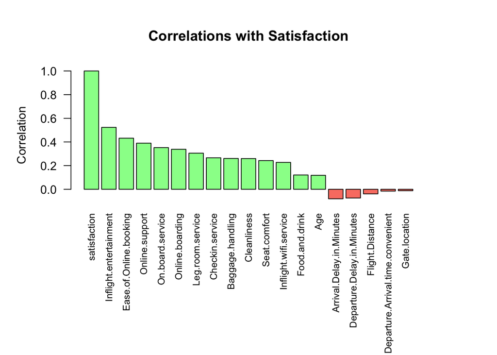

```r
par(mar = c(11,5,5,5))
barplot(satisfaction_correlation, main = "Correlations with Satisfaction",
        ylab = "Correlation", col = ifelse(satisfaction_correlation > 0, "palegreen", "salmon"),
        las = 2, cex.names = 0.8)
```

Here we can see that Inflight entertainment is the service that has the highest positive correlation with overall satisfaction, even if it’s only moderately correlated. This can be worth investigating further using logistic regression to get a deeper understanding of how the different services affect satisfaction.

### Key findings

- Business travel constitutes a significant portion (69%) of all travels.
- The distribution between Business Class and Economy Class is relatively even.
- Most Business travelers opt for Business Class, while a substantial proportion still chooses Economy or Economy Plus.
- Customers on Personal travels mainly choose Economy and Economy Plus classes.
- Overall satisfaction among airline customers is approximately 55%.
- Business travelers exhibit higher satisfaction levels compared to those making Personal travels.
- Satisfaction levels vary significantly between classes, with Business Class passengers being notably more satisfied than Economy and Economy Plus passengers.
- Examining age demographics, the majority of customers fall within the 20-60 age range.
- Overall, customers aged 41-60 tend to be the most satisfied across age groups.
- Breaking down satisfaction by age groups and classes reveals that Economy and Economy Plus passengers aged 21-30 are the least satisfied, while Business Class passengers aged 0-14 and 65+ show dissatisfaction.
- In terms of services, Inflight entertainment shows the highest positive correlation with overall satisfaction suggesting its importance in enhancing the customer experience.

### Recommendations:

- Further investigate the different services to understand how improvements can positively impact overall satisfaction.
- Address areas causing dissatisfaction among Economy and Economy Plus passengers to improve overall satisfaction.
- Implement targeted improvements for age groups showing lower satisfaction, especially for young Economy and Economy Plus passengers and older Business Class passengers.